# DNA Methylation Analysis of CTRL and DIS Samples

Illumina HumanMethylation450K Array Analysis | DNA & RNA Dynamics Final Project, Team 1

Fatemeh Bayat, Tamime Eter, Seyed Parsa Golshani, Amirhossein Heidari, Mahmoud Ahmed Mohamed Mohamed Ibrahim, Hector Eduardo Parga Najera, Bita Rahmani, Shayan Zanjaniha

June 2026

# Introduction

This report was prepared as the Team 1 final project for the DNA & RNA Dynamics course at Alma Mater Studiorum - Universita di Bologna. The assignment focuses on the analysis of DNA methylation array data using the R/Bioconductor `minfi` workflow and the specific methodological parameters assigned to Team 1.

DNA methylation is an epigenetic modification that contributes to gene regulation and can vary between biological conditions. In this project, Illumina HumanMethylation450K array data from CTRL and DIS samples are analyzed to evaluate whether methylation patterns differ between the two groups.

The workflow follows the assigned Team 1 pipeline using `minfi` for raw data import, quality control, normalization, exploratory visualization, and probe-wise differential methylation testing. The analysis includes raw fluorescence inspection, quality control, beta and M-value summaries, `preprocessNoob` normalization, PCA, t-tests between CTRL and DIS samples, multiple testing correction, volcano and Manhattan plots, and heatmap visualization of the top candidate probes. The results are interpreted cautiously because the dataset is small and the statistical analysis involves hundreds of thousands of CpG-level tests.

Team 1 assignments:

- Address for the fluorescence check: `42796479`
- Detection p-value threshold: `0.05`
- Normalization method: `preprocessNoob`
- Differential methylation test: `t-test`

# Analysis Workflow

## Step 00. Setup

Clean the workspace before starting the analysis.

```r
rm(list = ls())
```

Load all packages used by the complete workflow.

```r
library(minfi)
library(qqman)
library(gplots)
library(IlluminaHumanMethylation450kmanifest)
library(IlluminaHumanMethylation450kanno.ilmn12.hg19)
```

Define input and output folders relative to the repository root.

```r
baseDir <- "data/raw"
rdsDir <- "results/rds"
tablesDir <- "results/tables"
figuresDir <- "results/figures"
```

## Step 01. Data Import and RGChannelSet Creation

Check the raw data folder and read the sample sheet.

```r
list.files(baseDir)
```

```
##  [1] "GSM5319592_200121140049_R01C02_Grn.idat"
##  [2] "GSM5319592_200121140049_R01C02_Red.idat"
##  [3] "GSM5319603_3999356129_R02C02_Grn.idat"
##  [4] "GSM5319603_3999356129_R02C02_Red.idat"
##  [5] "GSM5319604_3999547012_R02C01_Grn.idat"
##  [6] "GSM5319604_3999547012_R02C01_Red.idat"
##  [7] "GSM5319607_3999547012_R03C02_Grn.idat"
##  [8] "GSM5319607_3999547012_R03C02_Red.idat"
##  [9] "GSM5319609_3999547016_R02C01_Grn.idat"
## [10] "GSM5319609_3999547016_R02C01_Red.idat"
## [11] "GSM5319613_3999547017_R02C01_Grn.idat"
## [12] "GSM5319613_3999547017_R02C01_Red.idat"
## [13] "GSM5319615_3999547017_R04C01_Grn.idat"
## [14] "GSM5319615_3999547017_R04C01_Red.idat"
## [15] "GSM5319616_3999547017_R06C01_Grn.idat"
## [16] "GSM5319616_3999547017_R06C01_Red.idat"
## [17] "SampleSheet_Report_II.csv"
```

```r
SampleSheet <- read.csv(file.path(baseDir, "SampleSheet_Report_II.csv"),
                        header = TRUE,
                        stringsAsFactors = FALSE)
head(SampleSheet)
```

|  | SampleID | Sex | Group | Sentrix_ID | Sentrix_Position |
| --- | --- | --- | --- | --- | --- |
| 1 | GSM5319592 | Male | CTRL | 200121140049 | R01C02 |
| 2 | GSM5319603 | Male | DIS | 3999356129 | R02C02 |
| 3 | GSM5319604 | Female | DIS | 3999547012 | R02C01 |
| 4 | GSM5319607 | Male | CTRL | 3999547012 | R03C02 |
| 5 | GSM5319609 | Female | DIS | 3999547016 | R02C01 |
| 6 | GSM5319613 | Female | DIS | 3999547017 | R02C01 |

Read the sample sheet with `minfi` and load the IDAT files into an `RGChannelSet` object called `RGset`.

```r
targets <- read.metharray.sheet(baseDir)
```

```
## [1] "data/raw/SampleSheet_Report_II.csv"
```

```r
targets
```

| SampleID | Sex | Group | Array | Slide | Basename |
| --- | --- | --- | --- | --- | --- |
| GSM5319592 | Male | CTRL | R01C02 | 200121140049 | data/raw/GSM5319592_200121140049_R01C02 |
| GSM5319603 | Male | DIS | R02C02 | 3999356129 | data/raw/GSM5319603_3999356129_R02C02 |
| GSM5319604 | Female | DIS | R02C01 | 3999547012 | data/raw/GSM5319604_3999547012_R02C01 |
| GSM5319607 | Male | CTRL | R03C02 | 3999547012 | data/raw/GSM5319607_3999547012_R03C02 |
| GSM5319609 | Female | DIS | R02C01 | 3999547016 | data/raw/GSM5319609_3999547016_R02C01 |
| GSM5319613 | Female | DIS | R02C01 | 3999547017 | data/raw/GSM5319613_3999547017_R02C01 |
| GSM5319615 | Female | CTRL | R04C01 | 3999547017 | data/raw/GSM5319615_3999547017_R04C01 |
| GSM5319616 | Female | CTRL | R06C01 | 3999547017 | data/raw/GSM5319616_3999547017_R06C01 |

```r
RGset <- read.metharray.exp(targets = targets)
```

Explore the `RGChannelSet` object.

```r
RGset
```

```
## class: RGChannelSet
## dim: 622399 8
## metadata(0):
## assays(2): Green Red
## rownames(622399): 10600313 10600322 ... 74810490 74810492
## rowData names(0):
## colnames(8): GSM5319592_200121140049_R01C02
##   GSM5319603_3999356129_R02C02 ... GSM5319615_3999547017_R04C01
##   GSM5319616_3999547017_R06C01
## colData names(7): SampleID Sex ... Basename filenames
## Annotation
##   array: IlluminaHumanMethylation450k
##   annotation: ilmn12.hg19
```

```r
class(RGset)
```

```
## [1] "RGChannelSet"
## attr(,"package")
## [1] "minfi"
```

```r
str(RGset)
```

The `SampleSheet` contains the metadata for our 8 samples, including group (CTRL/DIS), sex, and Sentrix ID/Position. `read.metharray.sheet()` reads this sheet and automatically attaches the file paths needed to locate the corresponding IDAT files. `read.metharray.exp()` then loads the raw Red and Green fluorescence intensities for all samples into an `RGChannelSet` object called `RGset`.

## Step 02. Red and Green Fluorescence Channels

Extract the raw Red and Green fluorescence intensity matrices from `RGset`. Each matrix has one row per probe address and one column per sample.

```r
Red <- data.frame(getRed(RGset))
dim(Red)
```

```
## [1] 622399      8
```

```r
head(Red)
```

|  | GSM5319592_200121140049_R01C02 | GSM5319603_3999356129_R02C02 | GSM5319604_3999547012_R02C01 | GSM5319607_3999547012_R03C02 | GSM5319609_3999547016_R02C01 | GSM5319613_3999547017_R02C01 | GSM5319615_3999547017_R04C01 | GSM5319616_3999547017_R06C01 |
| --- | --- | --- | --- | --- | --- | --- | --- | --- |
| 10600313 | 322 | 159 | 303 | 419 | 294 | 346 | 523 | 491 |
| 10600322 | 361 | 231 | 553 | 919 | 127 | 731 | 943 | 574 |
| 10600328 | 1522 | 469 | 1682 | 2301 | 1163 | 1085 | 1708 | 1250 |
| 10600336 | 4916 | 3034 | 9117 | 13823 | 2664 | 10864 | 12023 | 11925 |
| 10600345 | 875 | 252 | 1168 | 1326 | 457 | 1828 | 2138 | 899 |
| 10600353 | 596 | 205 | 556 | 860 | 477 | 444 | 632 | 478 |

```r
Green <- data.frame(getGreen(RGset))
dim(Green)
```

```
## [1] 622399      8
```

```r
head(Green)
```

|  | GSM5319592_200121140049_R01C02 | GSM5319603_3999356129_R02C02 | GSM5319604_3999547012_R02C01 | GSM5319607_3999547012_R03C02 | GSM5319609_3999547016_R02C01 | GSM5319613_3999547017_R02C01 | GSM5319615_3999547017_R04C01 | GSM5319616_3999547017_R06C01 |
| --- | --- | --- | --- | --- | --- | --- | --- | --- |
| 10600313 | 134 | 53 | 124 | 198 | 133 | 157 | 146 | 146 |
| 10600322 | 3109 | 1160 | 3546 | 5033 | 694 | 4135 | 4955 | 3743 |
| 10600328 | 1764 | 669 | 2246 | 2497 | 1820 | 1229 | 1827 | 1645 |
| 10600336 | 566 | 336 | 873 | 1279 | 275 | 804 | 1012 | 986 |
| 10600345 | 1558 | 277 | 1147 | 1555 | 558 | 2103 | 2053 | 1323 |
| 10600353 | 1903 | 476 | 1967 | 1994 | 1632 | 1595 | 2719 | 1889 |

## Step 03. Team 1 Address Check

Define the Team 1 address and look it up in the Type I and Type II probe information tables.

```r
TARGET_ADDRESS <- "42796479"

getManifest(RGset)
```

```
## IlluminaMethylationManifest object
## Annotation
##   array: IlluminaHumanMethylation450k
## Number of type I probes: 135476
## Number of type II probes: 350036
## Number of control probes: 850
## Number of SNP type I probes: 25
## Number of SNP type II probes: 40
```

```r
ProbeInfo_I  <- data.frame(getProbeInfo(RGset, type = "I"))
ProbeInfo_II <- data.frame(getProbeInfo(RGset, type = "II"))

ProbeInfo_I[ProbeInfo_I$AddressA == TARGET_ADDRESS, ]
```

|  | Name | AddressA | AddressB | Color | NextBase | ProbeSeqA | ProbeSeqB | nCpG |
| --- | --- | --- | --- | --- | --- | --- | --- | --- |
| 86494 | cg10602367 | 42796479 | 35778326 | Red | A | AAAACTCAAAACACCACACAAAAATACAACTACACCTCAAAAATAAAACA | AAAACTCGAAACGCCACGCGAAAATACAACTACACCTCGAAAATAAAACG | 5 |

```r
ProbeInfo_I[ProbeInfo_I$AddressB == TARGET_ADDRESS, ]
```

| Name | AddressA | AddressB | Color | NextBase | ProbeSeqA | ProbeSeqB | nCpG |
| --- | --- | --- | --- | --- | --- | --- | --- |

```r
ProbeInfo_II[ProbeInfo_II$AddressA == TARGET_ADDRESS, ]
```

| Name | AddressA | ProbeSeqA | nCpG |
| --- | --- | --- | --- |

Extract the Red and Green fluorescence values for address `42796479` and summarize them together with the probe annotation.

```r
Red_fluorescences <- Red[rownames(Red) == TARGET_ADDRESS, , drop = FALSE]
Green_fluorescences <- Green[rownames(Green) == TARGET_ADDRESS, , drop = FALSE]

df_summary_probes <- data.frame(
  Sample             = colnames(Red_fluorescences),
  Red_Fluorescence   = as.numeric(Red_fluorescences[1, ]),
  Green_Fluorescence = as.numeric(Green_fluorescences[1, ]),
  Type               = "I",
  Color              = "Red"
)

df_summary_probes
```

| Sample | Red_Fluorescence | Green_Fluorescence | Type | Color |
| --- | --- | --- | --- | --- |
| GSM5319592_200121140049_R01C02 | 3051 | 156 | I | Red |
| GSM5319603_3999356129_R02C02 | 2535 | 107 | I | Red |
| GSM5319604_3999547012_R02C01 | 7532 | 253 | I | Red |
| GSM5319607_3999547012_R03C02 | 10887 | 426 | I | Red |
| GSM5319609_3999547016_R02C01 | 2987 | 173 | I | Red |
| GSM5319613_3999547017_R02C01 | 6994 | 186 | I | Red |
| GSM5319615_3999547017_R04C01 | 8550 | 329 | I | Red |
| GSM5319616_3999547017_R06C01 | 9055 | 225 | I | Red |

Address `42796479` corresponds to the **AddressA (unmethylated)** position of probe **cg10602367**, a **Type I, Red-channel** probe. Type I probes use a single color channel, so the Green fluorescence values for this address are near background levels across all samples, while Red fluorescence varies between samples. This confirms that the assigned address is measured primarily in the Red channel; the sample-to-sample differences should be interpreted cautiously because raw fluorescence can reflect both biological and technical variation.

## Step 04. MethylSet Creation

Convert `RGset` to a raw `MethylSet` object without normalization.

```r
MSet.raw <- preprocessRaw(RGset)
MSet.raw
```

```
## class: MethylSet
## dim: 485512 8
## metadata(0):
## assays(2): Meth Unmeth
## rownames(485512): cg00050873 cg00212031 ... ch.22.47579720R
##   ch.22.48274842R
## rowData names(0):
## colnames(8): GSM5319592_200121140049_R01C02
##   GSM5319603_3999356129_R02C02 ... GSM5319615_3999547017_R04C01
##   GSM5319616_3999547017_R06C01
## colData names(7): SampleID Sex ... Basename filenames
## Annotation
##   array: IlluminaHumanMethylation450k
##   annotation: ilmn12.hg19
## Preprocessing
##   Method: Raw (no normalization or bg correction)
##   minfi version: 1.56.0
##   Manifest version: 0.4.0
```

Extract the methylated and unmethylated signal matrices from `MSet.raw`.

```r
Meth <- as.matrix(getMeth(MSet.raw))
head(Meth)
```

```
##            GSM5319592_200121140049_R01C02 GSM5319603_3999356129_R02C02
## cg00050873                           5938                         2879
## cg00212031                            174                          156
## cg00213748                            521                          285
## cg00214611                            144                           76
## cg00455876                           1557                          820
## cg01707559                            415                          298
##            GSM5319604_3999547012_R02C01 GSM5319607_3999547012_R03C02
## cg00050873                          336                         6349
## cg00212031                          177                          306
## cg00213748                          237                         1194
## cg00214611                          195                          334
## cg00455876                          207                         4630
## cg01707559                          410                          498
##            GSM5319609_3999547016_R02C01 GSM5319613_3999547017_R02C01
## cg00050873                          428                          233
## cg00212031                          184                          229
## cg00213748                          146                          120
## cg00214611                          169                          253
## cg00455876                          141                          163
## cg01707559                          407                          350
##            GSM5319615_3999547017_R04C01 GSM5319616_3999547017_R06C01
## cg00050873                          305                          535
## cg00212031                          196                          258
## cg00213748                          183                          271
## cg00214611                          287                          216
## cg00455876                          281                          261
## cg01707559                          419                          306
```

```r
Unmeth <- as.matrix(getUnmeth(MSet.raw))
head(Unmeth)
```

```
##            GSM5319592_200121140049_R01C02 GSM5319603_3999356129_R02C02
## cg00050873                            422                          392
## cg00212031                           1234                          902
## cg00213748                            129                           72
## cg00214611                           1354                          705
## cg00455876                            574                          543
## cg01707559                           2968                         1844
##            GSM5319604_3999547012_R02C01 GSM5319607_3999547012_R03C02
## cg00050873                          197                          425
## cg00212031                          222                         5017
## cg00213748                          284                          306
## cg00214611                          258                         4616
## cg00455876                          646                         1195
## cg01707559                         1030                         8715
##            GSM5319609_3999547016_R02C01 GSM5319613_3999547017_R02C01
## cg00050873                          215                          243
## cg00212031                          304                          309
## cg00213748                          110                          171
## cg00214611                          198                          131
## cg00455876                          385                          488
## cg01707559                          929                          541
##            GSM5319615_3999547017_R04C01 GSM5319616_3999547017_R06C01
## cg00050873                          197                          312
## cg00212031                          278                          308
## cg00213748                          187                          254
## cg00214611                          190                          222
## cg00455876                          518                          656
## cg01707559                          849                          563
```

```r
str(Meth)
str(Unmeth)
```

Check probe `cg10602367`, identified from the Team 1 address in Step 03.

```r
Meth[rownames(Meth) == "cg10602367", , drop = FALSE]
```

```
##            GSM5319592_200121140049_R01C02 GSM5319603_3999356129_R02C02
## cg10602367                            136                           30
##            GSM5319604_3999547012_R02C01 GSM5319607_3999547012_R03C02
## cg10602367                          230                          286
##            GSM5319609_3999547016_R02C01 GSM5319613_3999547017_R02C01
## cg10602367                          194                          231
##            GSM5319615_3999547017_R04C01 GSM5319616_3999547017_R06C01
## cg10602367                          164                          270
```

```r
Unmeth[rownames(Unmeth) == "cg10602367", , drop = FALSE]
```

```
##            GSM5319592_200121140049_R01C02 GSM5319603_3999356129_R02C02
## cg10602367                           3051                         2535
##            GSM5319604_3999547012_R02C01 GSM5319607_3999547012_R03C02
## cg10602367                         7532                        10887
##            GSM5319609_3999547016_R02C01 GSM5319613_3999547017_R02C01
## cg10602367                         2987                         6994
##            GSM5319615_3999547017_R04C01 GSM5319616_3999547017_R06C01
## cg10602367                         8550                         9055
```

`preprocessRaw()` converts the raw Red/Green intensities in `RGset` into a `MethylSet`, splitting the signal into **Methylated** and **Unmethylated** intensities for each probe. For our probe `cg10602367`, the Unmethylated signal is substantially higher than the Methylated signal across all 8 samples, consistent with the Red-channel Type I design identified in Step 3.

## Step 05. Quality Control

### 5.1 QC Plot

Calculate median methylated and unmethylated signal intensities for each sample and display the QC plot.

```r
qc <- getQC(MSet.raw)
qc
```

```
## DataFrame with 8 rows and 2 columns
##                                     mMed      uMed
##                                <numeric> <numeric>
## GSM5319592_200121140049_R01C02  10.26327   9.76321
## GSM5319603_3999356129_R02C02     8.62205   8.82018
## GSM5319604_3999547012_R02C01    10.35094  10.23721
## GSM5319607_3999547012_R03C02    10.79360  10.90313
## GSM5319609_3999547016_R02C01     8.82655   8.83289
## GSM5319613_3999547017_R02C01    10.83684  10.69523
## GSM5319615_3999547017_R04C01    11.15038  11.04644
## GSM5319616_3999547017_R06C01    10.27845  10.33316
```

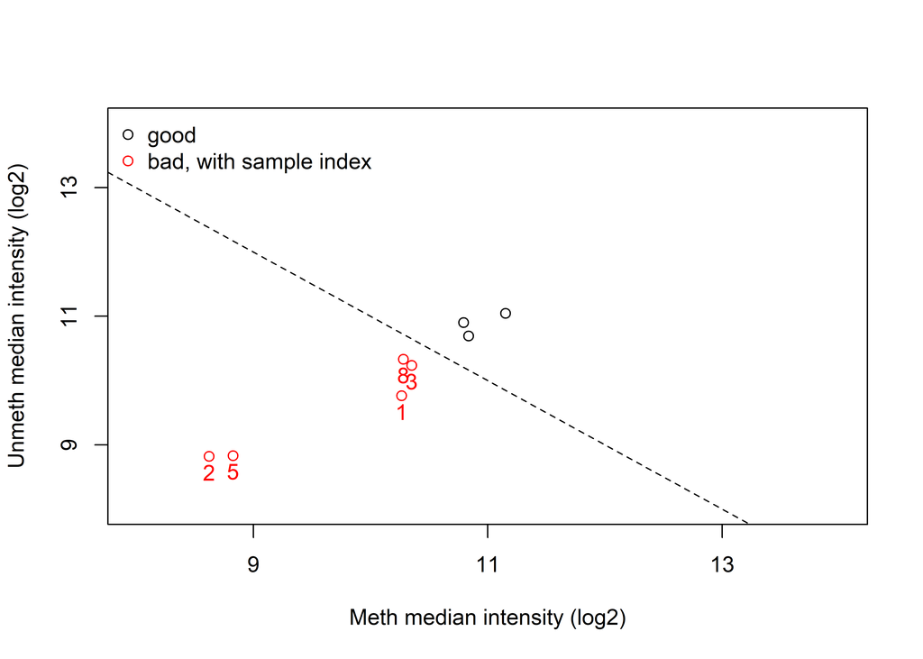

```r
plotQC(qc)
```

**Interpretation:** The QC plot summarizes the median methylated and unmethylated signal intensities for each sample on the log2 scale. Several samples are flagged by this median-intensity criterion, indicating lower overall signal intensity compared with the other arrays. However, this plot alone is not sufficient to discard samples because it does not directly evaluate whether probe signals are distinguishable from background. Therefore, the QC plot should be interpreted together with the negative control intensities and detection p-values below.

### 5.2 Negative Control Intensities

Extract control probes from the array and plot the negative control intensities.

```r
NegativeControl <- data.frame(getProbeInfo(RGset, type = "Control"))
table(NegativeControl$Type)
```

```
##
##  BISULFITE CONVERSION I BISULFITE CONVERSION II               EXTENSION
##                      12                       4                       4
##           HYBRIDIZATION                NEGATIVE         NON-POLYMORPHIC
##                       3                     613                       4
##                  NORM_A                  NORM_C                  NORM_G
##                      32                      61                      32
##                  NORM_T             RESTORATION           SPECIFICITY I
##                      61                       1                      12
##          SPECIFICITY II                STAINING          TARGET REMOVAL
##                       3                       4                       2
```

```r
head(NegativeControl)
```

|  | Address | Type | Color | ExtendedType |
| --- | --- | --- | --- | --- |
| 1 | 27630314 | STAINING | Red | DNP (High) |
| 2 | 43603326 | STAINING | Purple | DNP (Bkg) |
| 3 | 41666334 | STAINING | Green | Biotin (High) |
| 4 | 34648333 | STAINING | Blue | Biotin (Bkg) |
| 5 | 63642461 | EXTENSION | Red | Extension (A) |
| 6 | 47640365 | EXTENSION | Purple | Extension (T) |

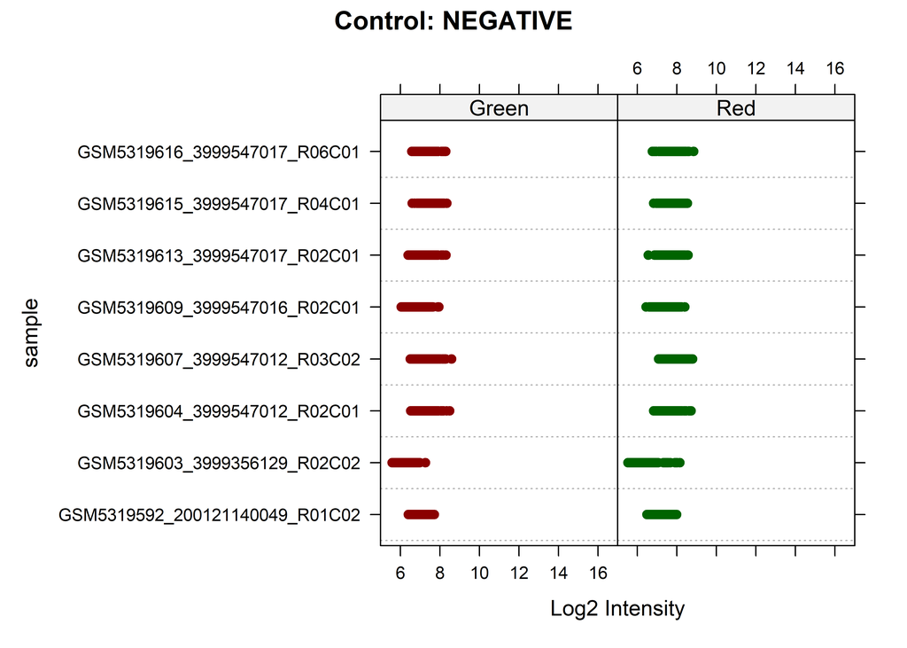

```r
controlStripPlot(RGset, controls = "NEGATIVE")
```

**Interpretation:** Negative control probes are expected to show low fluorescence intensity because their sequences should not hybridize to human DNA. In this plot, the negative controls remain low in both the Green and Red channels, mostly below about 10 on the log2 intensity scale. This indicates that background fluorescence and nonspecific hybridization are not excessive in these arrays. Together with the detection p-value results, this supports keeping the samples for downstream analysis despite the lower median intensities observed for some arrays in the QC plot.

### 5.3 Detection P-values

Calculate detection p-values and identify failed probe-sample tests using Team 1’s threshold of 0.05.

```r
DETECTION_P_THRESHOLD <- 0.05
detP <- detectionP(RGset)

Over_Threshold <- detP > DETECTION_P_THRESHOLD
table(Over_Threshold)
```

```
## Over_Threshold
##   FALSE    TRUE
## 3877813    6283
```

```r
sum(Over_Threshold)
```

```
## [1] 6283
```

```r
Total_Failed_Positions <- sum(Over_Threshold)
Total_Detection_Tests <- length(Over_Threshold)
Total_Failed_Percentage <- Total_Failed_Positions / Total_Detection_Tests * 100

Over_Threshold_Per_Sample <- colSums(Over_Threshold)
Over_Threshold_Per_Sample
```

```
## GSM5319592_200121140049_R01C02   GSM5319603_3999356129_R02C02
##                            202                            306
##   GSM5319604_3999547012_R02C01   GSM5319607_3999547012_R03C02
##                           1156                            366
##   GSM5319609_3999547016_R02C01   GSM5319613_3999547017_R02C01
##                           2735                            460
##   GSM5319615_3999547017_R04C01   GSM5319616_3999547017_R06C01
##                            384                            674
```

```r
Over_Threshold_Fraction_Per_Sample <- colMeans(Over_Threshold)
Over_Threshold_Fraction_Per_Sample
```

```
## GSM5319592_200121140049_R01C02   GSM5319603_3999356129_R02C02
##                   0.0004160556                   0.0006302625
##   GSM5319604_3999547012_R02C01   GSM5319607_3999547012_R03C02
##                   0.0023809916                   0.0007538434
##   GSM5319609_3999547016_R02C01   GSM5319613_3999547017_R02C01
##                   0.0056332284                   0.0009474534
##   GSM5319615_3999547017_R04C01   GSM5319616_3999547017_R06C01
##                   0.0007909176                   0.0013882252
```

```r
failed <- data.frame(
  Sample = names(Over_Threshold_Per_Sample),
  n_Failed_Positions = Over_Threshold_Per_Sample,
  Percentage_Failed_Positions = Over_Threshold_Fraction_Per_Sample * 100,
  row.names = NULL
)
failed
```

| Sample | n_Failed_Positions | Percentage_Failed_Positions |
| --- | --- | --- |
| GSM5319592_200121140049_R01C02 | 202 | 0.04160556 |
| GSM5319603_3999356129_R02C02 | 306 | 0.06302625 |
| GSM5319604_3999547012_R02C01 | 1156 | 0.23809916 |
| GSM5319607_3999547012_R03C02 | 366 | 0.07538434 |
| GSM5319609_3999547016_R02C01 | 2735 | 0.56332284 |
| GSM5319613_3999547017_R02C01 | 460 | 0.09474534 |
| GSM5319615_3999547017_R04C01 | 384 | 0.07909176 |
| GSM5319616_3999547017_R06C01 | 674 | 0.13882252 |

**Interpretation:** Using Team 1’s detection p-value threshold of 0.05, there are 6283 failed detection tests across all samples, corresponding to 0.16% of all probe-sample detection tests. Per sample, the number of failed positions ranges from 202 to 2735, corresponding to 0.04% to 0.56% of positions. Because the failed fraction is low for every sample, most probes are distinguishable from background. Therefore, no sample needs to be removed at this stage.

## Step 06. Raw Beta and M Values

Retrieve beta and M value matrices from the raw `MethylSet`.

Extract raw beta values and inspect their dimensions and distribution.

```r
beta <- getBeta(MSet.raw)
class(beta)
```

```
## [1] "matrix" "array"
```

```r
dim(beta)
```

```
## [1] 485512      8
```

```r
head(beta)
```

```
##            GSM5319592_200121140049_R01C02 GSM5319603_3999356129_R02C02
## cg00050873                     0.93364780                   0.88015897
## cg00212031                     0.12357955                   0.14744802
## cg00213748                     0.80153846                   0.79831933
## cg00214611                     0.09612817                   0.09731114
## cg00455876                     0.73064289                   0.60161409
## cg01707559                     0.12267218                   0.13912232
##            GSM5319604_3999547012_R02C01 GSM5319607_3999547012_R03C02
## cg00050873                    0.6303940                   0.93726011
## cg00212031                    0.4436090                   0.05748638
## cg00213748                    0.4548944                   0.79600000
## cg00214611                    0.4304636                   0.06747475
## cg00455876                    0.2426729                   0.79484979
## cg01707559                    0.2847222                   0.05405405
##            GSM5319609_3999547016_R02C01 GSM5319613_3999547017_R02C01
## cg00050873                    0.6656299                    0.4894958
## cg00212031                    0.3770492                    0.4256506
## cg00213748                    0.5703125                    0.4123711
## cg00214611                    0.4604905                    0.6588542
## cg00455876                    0.2680608                    0.2503840
## cg01707559                    0.3046407                    0.3928171
##            GSM5319615_3999547017_R04C01 GSM5319616_3999547017_R06C01
## cg00050873                    0.6075697                    0.6316411
## cg00212031                    0.4135021                    0.4558304
## cg00213748                    0.4945946                    0.5161905
## cg00214611                    0.6016771                    0.4931507
## cg00455876                    0.3516896                    0.2846238
## cg01707559                    0.3304416                    0.3521289
```

```r
summary(beta)
```

```
##  GSM5319592_200121140049_R01C02 GSM5319603_3999356129_R02C02
##  Min.   :0.0000                 Min.   :0.0000
##  1st Qu.:0.1191                 1st Qu.:0.1225
##  Median :0.6961                 Median :0.6108
##  Mean   :0.5316                 Mean   :0.4982
##  3rd Qu.:0.8675                 3rd Qu.:0.8053
##  Max.   :0.9928                 Max.   :1.0000
##  NA's   :3                      NA's   :13
##  GSM5319604_3999547012_R02C01 GSM5319607_3999547012_R03C02
##  Min.   :0.00000              Min.   :0.00000
##  1st Qu.:0.09519              1st Qu.:0.08539
##  Median :0.63998              Median :0.63196
##  Mean   :0.50782              Mean   :0.49501
##  3rd Qu.:0.84141              3rd Qu.:0.82463
##  Max.   :0.99817              Max.   :1.00000
##  NA's   :9                    NA's   :9
##  GSM5319609_3999547016_R02C01 GSM5319613_3999547017_R02C01
##  Min.   :0.0000               Min.   :0.0000
##  1st Qu.:0.1510               1st Qu.:0.0737
##  Median :0.5777               Median :0.6349
##  Mean   :0.4917               Mean   :0.4964
##  3rd Qu.:0.7727               3rd Qu.:0.8439
##  Max.   :1.0000               Max.   :1.0000
##  NA's   :2                    NA's   :2
##  GSM5319615_3999547017_R04C01 GSM5319616_3999547017_R06C01
##  Min.   :0.00000              Min.   :0.00000
##  1st Qu.:0.08599              1st Qu.:0.08401
##  Median :0.62261              Median :0.63024
##  Mean   :0.49733              Mean   :0.49650
##  3rd Qu.:0.82990              3rd Qu.:0.83153
##  Max.   :1.00000              Max.   :1.00000
##  NA's   :3                    NA's   :1
```

Extract raw M values and inspect their dimensions and distribution.

```r
M <- getM(MSet.raw)
dim(M)
```

```
## [1] 485512      8
```

```r
head(M)
```

```
##            GSM5319592_200121140049_R01C02 GSM5319603_3999356129_R02C02
## cg00050873                       3.814662                    2.8766422
## cg00212031                      -2.826183                   -2.5315814
## cg00213748                       2.013912                    1.9848931
## cg00214611                      -3.233087                   -3.2135519
## cg00455876                       1.439646                    0.5946717
## cg01707559                      -2.838308                   -2.6294544
##            GSM5319604_3999547012_R02C01 GSM5319607_3999547012_R03C02
## cg00050873                    0.7702656                     3.900995
## cg00212031                   -0.3268103                    -4.035221
## cg00213748                   -0.2610039                     1.964199
## cg00214611                   -0.4038969                    -3.788723
## cg00455876                   -1.6419034                     1.954002
## cg01707559                   -1.3289485                    -4.129283
##            GSM5319609_3999547016_R02C01 GSM5319613_3999547017_R02C01
## cg00050873                    0.9932741                  -0.06062636
## cg00212031                   -0.7243656                  -0.43225924
## cg00213748                    0.4084648                  -0.51096192
## cg00214611                   -0.2284772                   0.94957057
## cg00455876                   -1.4491633                  -1.58200918
## cg01707559                   -1.1906498                  -0.62827367
##            GSM5319615_3999547017_R04C01 GSM5319616_3999547017_R06C01
## cg00050873                   0.63061361                   0.77799286
## cg00212031                  -0.50423123                  -0.25555929
## cg00213748                  -0.03119462                   0.09346435
## cg00214611                   0.59505132                  -0.03952836
## cg00455876                  -0.88238197                  -1.32964601
## cg01707559                  -1.01881431                  -0.87960327
```

```r
summary(M)
```

```
##  GSM5319592_200121140049_R01C02 GSM5319603_3999356129_R02C02
##  Min.   :  -Inf                 Min.   :   -Inf
##  1st Qu.:-2.887                 1st Qu.:-2.8402
##  Median : 1.196                 Median : 0.6499
##  Mean   :  -Inf                 Mean   :    NaN
##  3rd Qu.: 2.711                 3rd Qu.: 2.0480
##  Max.   : 7.102                 Max.   :    Inf
##  NA's   :3                      NA's   :13
##  GSM5319604_3999547012_R02C01 GSM5319607_3999547012_R03C02
##  Min.   :  -Inf               Min.   :  -Inf
##  1st Qu.:-3.249               1st Qu.:-3.421
##  Median : 0.830               Median : 0.780
##  Mean   :  -Inf               Mean   :   NaN
##  3rd Qu.: 2.408               3rd Qu.: 2.233
##  Max.   : 9.090               Max.   :   Inf
##  NA's   :9                    NA's   :9
##  GSM5319609_3999547016_R02C01 GSM5319613_3999547017_R02C01
##  Min.   :  -Inf               Min.   :  -Inf
##  1st Qu.:-2.491               1st Qu.:-3.652
##  Median : 0.452               Median : 0.798
##  Mean   :   NaN               Mean   :   NaN
##  3rd Qu.: 1.765               3rd Qu.: 2.434
##  Max.   :   Inf               Max.   :   Inf
##  NA's   :2                    NA's   :2
##  GSM5319615_3999547017_R04C01 GSM5319616_3999547017_R06C01
##  Min.   :   -Inf              Min.   :   -Inf
##  1st Qu.:-3.4099              1st Qu.:-3.4468
##  Median : 0.7223              Median : 0.7693
##  Mean   :    NaN              Mean   :    NaN
##  3rd Qu.: 2.2865              3rd Qu.: 2.3033
##  Max.   :    Inf              Max.   :    Inf
##  NA's   :3                    NA's   :1
```

Recover phenotype data to split samples by group.

```r
pheno <- data.frame(pData(RGset))
table(pheno$Group)
```

```
##
## CTRL  DIS
##    4    4
```

```r
str(pheno)
```

Split beta values into CTRL and DIS groups.

```r
beta_CTRL <- beta[, pheno$Group == "CTRL"]
beta_DIS <- beta[, pheno$Group == "DIS"]

dim(beta_CTRL)
```

```
## [1] 485512      4
```

```r
dim(beta_DIS)
```

```
## [1] 485512      4
```

Split M values into CTRL and DIS groups.

```r
M_CTRL <- M[, pheno$Group == "CTRL"]
M_DIS <- M[, pheno$Group == "DIS"]

dim(M_CTRL)
```

```
## [1] 485512      4
```

```r
dim(M_DIS)
```

```
## [1] 485512      4
```

Calculate mean beta and M values per CpG within each group.

```r
mean_of_beta_CTRL <- apply(beta_CTRL, 1, mean, na.rm = TRUE)
mean_of_beta_DIS <- apply(beta_DIS, 1, mean, na.rm = TRUE)

mean_of_M_CTRL <- apply(M_CTRL, 1, mean, na.rm = TRUE)
mean_of_M_DIS <- apply(M_DIS, 1, mean, na.rm = TRUE)
```

Remove infinite M values before density estimation.

```r
mean_of_M_CTRL <- mean_of_M_CTRL[is.finite(mean_of_M_CTRL)]
mean_of_M_DIS <- mean_of_M_DIS[is.finite(mean_of_M_DIS)]
```

Estimate density distributions for raw beta and M means.

```r
d_mean_of_beta_CTRL <- density(mean_of_beta_CTRL, na.rm = TRUE)
d_mean_of_beta_DIS <- density(mean_of_beta_DIS, na.rm = TRUE)

d_mean_of_M_CTRL <- density(mean_of_M_CTRL, na.rm = TRUE)
d_mean_of_M_DIS <- density(mean_of_M_DIS, na.rm = TRUE)
```

Plot raw beta density distributions by group.

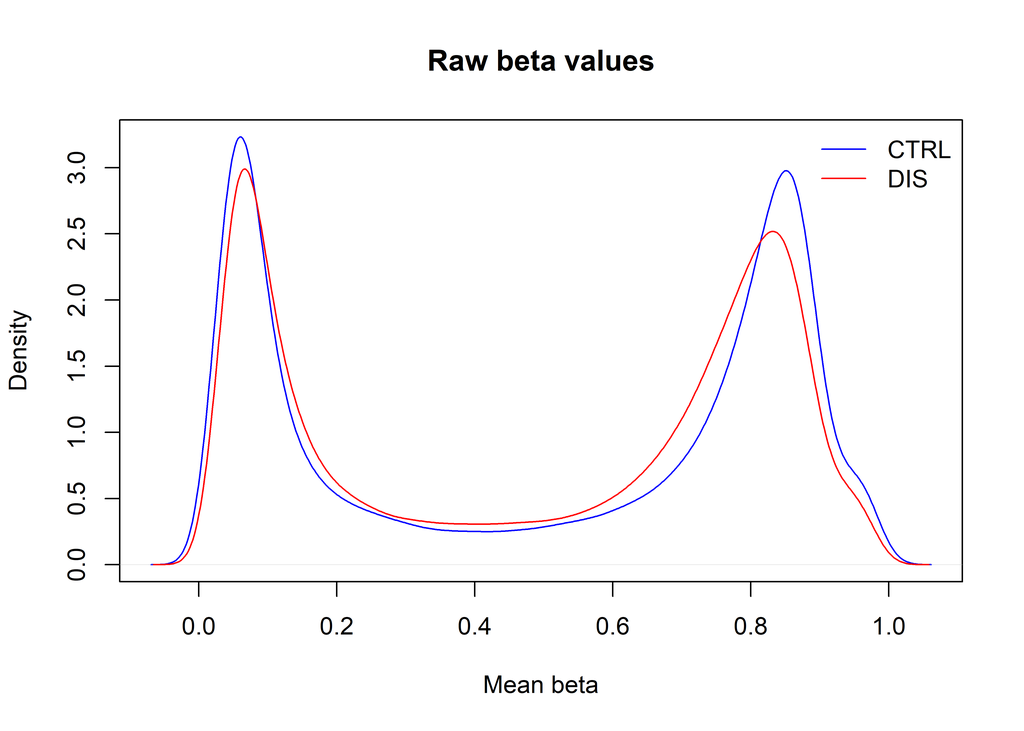

```r
plot(d_mean_of_beta_CTRL, col = "blue",
     main = "Raw beta values", xlab = "Mean beta")

lines(d_mean_of_beta_DIS, col = "red")

legend("topright", legend = c("CTRL", "DIS"),
       col = c("blue", "red"), lty = 1, bty = "n")
```

Plot raw M value density distributions by group.

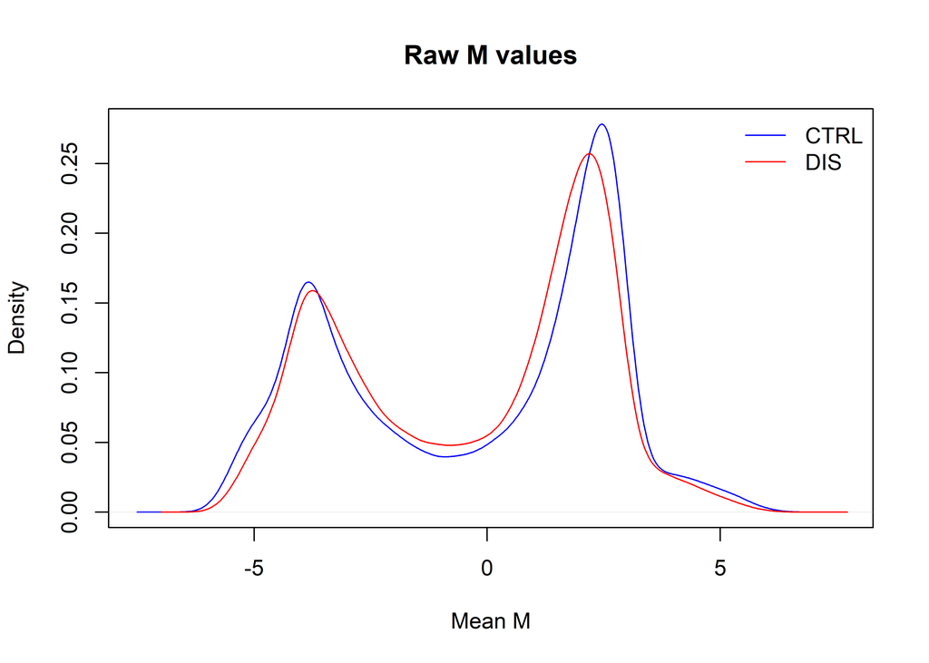

```r
plot(d_mean_of_M_CTRL, col = "blue",
     main = "Raw M values", xlab = "Mean M")

lines(d_mean_of_M_DIS, col = "red")

legend("topright", legend = c("CTRL", "DIS"),
       col = c("blue", "red"), lty = 1, bty = "n")
```

**Interpretation:** The raw beta and M-value density curves for CTRL and DIS samples show broadly similar distributions. Small shifts between the two groups can be observed, but the overall methylation profiles are largely comparable at the raw-data level.

## Step 07. Normalization with preprocessNoob

The assigned Team 1 normalization method was `preprocessNoob`. Raw and normalized beta values were compared by Type I and Type II probe chemistry. This comparison is important because Infinium Type I and Type II assays can show systematic differences: Type II beta values tend to be shifted toward intermediate methylation levels and can show different variability from Type I probes. Normalization is used to reduce technical variation before biological interpretation.

### 7.1 Raw Beta Values by Probe Chemistry

Inspect the raw RGChannelSet and beta matrix.

```r
dim(beta)
```

```
## [1] 485512      8
```

```r
RGset
```

```r
head(beta)
```

Retrieve Type I and Type II probe annotations from the manifest.

```r
dfI <- data.frame(getProbeInfo(RGset, type = "I"))
dfII <- data.frame(getProbeInfo(RGset, type = "II"))

dim(dfI)
```

```
## [1] 135476      8
```

```r
dim(dfII)
```

```
## [1] 350036      4
```

```r
str(dfI)
str(dfII)
head(dfI$Name)
head(dfII$Name)
```

Split raw beta values by probe chemistry.

```r
beta_I <- beta[rownames(beta) %in% dfI$Name, ]
beta_II <- beta[rownames(beta) %in% dfII$Name, ]

dim(beta_I)
```

```
## [1] 135476      8
```

```r
dim(beta_II)
```

```
## [1] 350036      8
```

Calculate mean raw beta by probe chemistry.

```r
mean_of_beta_I <- apply(beta_I, 1, mean, na.rm = TRUE)
mean_of_beta_II <- apply(beta_II, 1, mean, na.rm = TRUE)
```

Estimate density of raw beta means by probe chemistry.

```r
d_mean_of_beta_I <- density(mean_of_beta_I, na.rm = TRUE)
d_mean_of_beta_II <- density(mean_of_beta_II, na.rm = TRUE)
```

Calculate and estimate density of raw beta standard deviations.

```r
sd_of_beta_I <- apply(beta_I, 1, sd, na.rm = TRUE)
sd_of_beta_II <- apply(beta_II, 1, sd, na.rm = TRUE)

d_sd_of_beta_I <- density(sd_of_beta_I, na.rm = TRUE)
d_sd_of_beta_II <- density(sd_of_beta_II, na.rm = TRUE)
```

### 7.2 Normalization with preprocessNoob

Normalize the raw RGChannelSet with preprocessNoob.

```r
preprocessNoob_results <- preprocessNoob(RGset)
```

Inspect the normalized object.

```r
class(preprocessNoob_results)
```

```
## [1] "MethylSet"
## attr(,"package")
## [1] "minfi"
```

```r
preprocessNoob_results
str(preprocessNoob_results)
```

Extract normalized beta and M values.

```r
beta_preprocessNoob <- getBeta(preprocessNoob_results)
M_preprocessNoob <- getM(preprocessNoob_results)

dim(beta_preprocessNoob)
```

```
## [1] 485512      8
```

```r
head(beta_preprocessNoob)
```

### 7.3 Normalized Beta Values by Probe Chemistry

Split normalized beta values by probe chemistry.

```r
beta_preprocessNoob_I <- beta_preprocessNoob[rownames(beta_preprocessNoob) %in% dfI$Name, ]
beta_preprocessNoob_II <- beta_preprocessNoob[rownames(beta_preprocessNoob) %in% dfII$Name, ]
```

Calculate mean normalized beta values by probe chemistry.

```r
mean_of_beta_preprocessNoob_I <- apply(beta_preprocessNoob_I, 1, mean, na.rm = TRUE)
mean_of_beta_preprocessNoob_II <- apply(beta_preprocessNoob_II, 1, mean, na.rm = TRUE)
```

Estimate density of normalized beta means.

```r
d_mean_of_beta_preprocessNoob_I <- density(mean_of_beta_preprocessNoob_I, na.rm = TRUE)
d_mean_of_beta_preprocessNoob_II <- density(mean_of_beta_preprocessNoob_II, na.rm = TRUE)
```

Calculate and estimate density of normalized beta standard deviations.

```r
sd_of_beta_preprocessNoob_I <- apply(beta_preprocessNoob_I, 1, sd, na.rm = TRUE)
sd_of_beta_preprocessNoob_II <- apply(beta_preprocessNoob_II, 1, sd, na.rm = TRUE)

d_sd_of_beta_preprocessNoob_I <- density(sd_of_beta_preprocessNoob_I, na.rm = TRUE)
d_sd_of_beta_preprocessNoob_II <- density(sd_of_beta_preprocessNoob_II, na.rm = TRUE)
```

### 7.4 Raw vs Normalized Six-panel Comparison

Define colors for the raw and normalized beta boxplots.

```r
pheno <- data.frame(pData(RGset))

type_col <- c("Type I" = "blue", "Type II" = "red")
group_col <- c(CTRL = "violet", DIS = "orange")
boxplot_col <- group_col[as.character(pheno$Group)]
```

Compare raw and normalized beta values using plots.

```r
# Plot raw and normalized beta-value comparisons
par(mfrow = c(2, 3), mar = c(7, 4.5, 3, 1), oma = c(1, 1, 1, 1))

# Panel 1: Raw beta mean density by probe type.
plot(d_mean_of_beta_I, col = type_col["Type I"], main = "Raw beta")
lines(d_mean_of_beta_II, col = type_col["Type II"])
legend("topright", legend = names(type_col), col = type_col,
       lty = 1, bty = "n", cex = 0.8)

# Panel 2: Raw beta standard deviation density by probe type.
plot(d_sd_of_beta_I, col = type_col["Type I"], main = "Raw SD")
lines(d_sd_of_beta_II, col = type_col["Type II"])
legend("topright", legend = names(type_col), col = type_col,
       lty = 1, bty = "n", cex = 0.8)

# Panel 3: Raw beta boxplot by sample group.
boxplot(beta, ylim = c(0, 1), col = boxplot_col, main = "Raw beta",
        names = FALSE)
axis(1, at = seq_len(ncol(beta)), labels = seq_len(ncol(beta)), cex.axis = 0.8)
usr <- par("usr")
legend(x = mean(usr[1:2]), y = usr[3] - 0.16 * diff(usr[3:4]),
       legend = names(group_col), xjust = 0.5, yjust = 1,
       fill = group_col, title = "Samples", horiz = TRUE, bty = "n",
       cex = 0.85, xpd = NA)

# Panel 4: Noob-normalized beta mean density by probe type.
plot(d_mean_of_beta_preprocessNoob_I, col = type_col["Type I"],
     main = "Noob beta")
lines(d_mean_of_beta_preprocessNoob_II, col = type_col["Type II"])
legend("topright", legend = names(type_col), col = type_col,
       lty = 1, bty = "n", cex = 0.8)

# Panel 5: Noob-normalized beta standard deviation density by probe type.
plot(d_sd_of_beta_preprocessNoob_I, col = type_col["Type I"],
     main = "Noob SD")
lines(d_sd_of_beta_preprocessNoob_II, col = type_col["Type II"])
legend("topright", legend = names(type_col), col = type_col,
       lty = 1, bty = "n", cex = 0.8)

# Panel 6: Noob-normalized beta boxplot by sample group.
boxplot(beta_preprocessNoob, ylim = c(0, 1), col = boxplot_col,
        main = "Noob beta", names = FALSE)
axis(1, at = seq_len(ncol(beta_preprocessNoob)), labels = seq_len(ncol(beta_preprocessNoob)), cex.axis = 0.8)
usr <- par("usr")
legend(x = mean(usr[1:2]), y = usr[3] - 0.16 * diff(usr[3:4]),
       legend = names(group_col), xjust = 0.5, yjust = 1,
       fill = group_col, title = "Samples", horiz = TRUE, bty = "n",
       cex = 0.85, xpd = NA)
```

[figure not shown]

**Interpretation:** In the density plots, blue lines represent Type I probes and red lines represent Type II probes, while in the boxplots violet boxes represent CTRL samples and orange boxes represent DIS samples. The `preprocessNoob` method is appropriate for this dataset because it performs background correction and dye-bias correction while preserving the overall structure of the beta-value distributions. In the six-panel comparison, the raw and normalized beta-value densities remain within the expected 0 to 1 range and keep the typical bimodal methylation pattern. Type I and Type II probes still show different distributional shapes, which is expected for Illumina methylation arrays and does not by itself indicate a failed normalization. In the group-colored boxplots, CTRL and DIS samples have broadly comparable medians and interquartile ranges before and after normalization, without a strong group-specific distribution shift. This suggests that normalization did not introduce an obvious artificial separation between groups and that the normalized beta values are suitable for the downstream PCA and t-test analyses.

## Step 08. PCA on Normalized Beta Values

PCA evaluates global sample structure and helps check whether major variation follows disease group, sex, or Sentrix_ID/batch.

Extract sample information and prepare grouping variables for PCA plots. In the `RGset` metadata, the Sentrix_ID information from the sample sheet is stored in the `Slide` column, so we create a `Sentrix_ID` variable from `Slide` for the batch-colored PCA.

```r
sample_info <- data.frame(pData(RGset))
sample_info$Group <- factor(sample_info$Group)
sample_info$Sex <- factor(sample_info$Sex)

# In pData(RGset), Sentrix_ID is stored as Slide.
sample_info$Sentrix_ID <- factor(sample_info$Slide)
```

### 8.1 Perform PCA

Run PCA on the transposed normalized beta matrix, because probes are rows and samples are columns.

```r
pca_results <- prcomp(t(beta_preprocessNoob), scale. = TRUE)

pca_var <- pca_results$sdev^2
pca_var_explained <- pca_var / sum(pca_var)
pca_var_cumulative <- cumsum(pca_var_explained)

x_padding <- diff(range(pca_results$x[, "PC1"])) * 0.12
y_padding <- diff(range(pca_results$x[, "PC2"])) * 0.12
xlim_pca <- range(pca_results$x[, "PC1"]) + c(-x_padding, x_padding)
ylim_pca <- range(pca_results$x[, "PC2"]) + c(-y_padding, y_padding)
```

### 8.2 Scree Plot

Plot the proportion of variance explained by the first eight principal components.

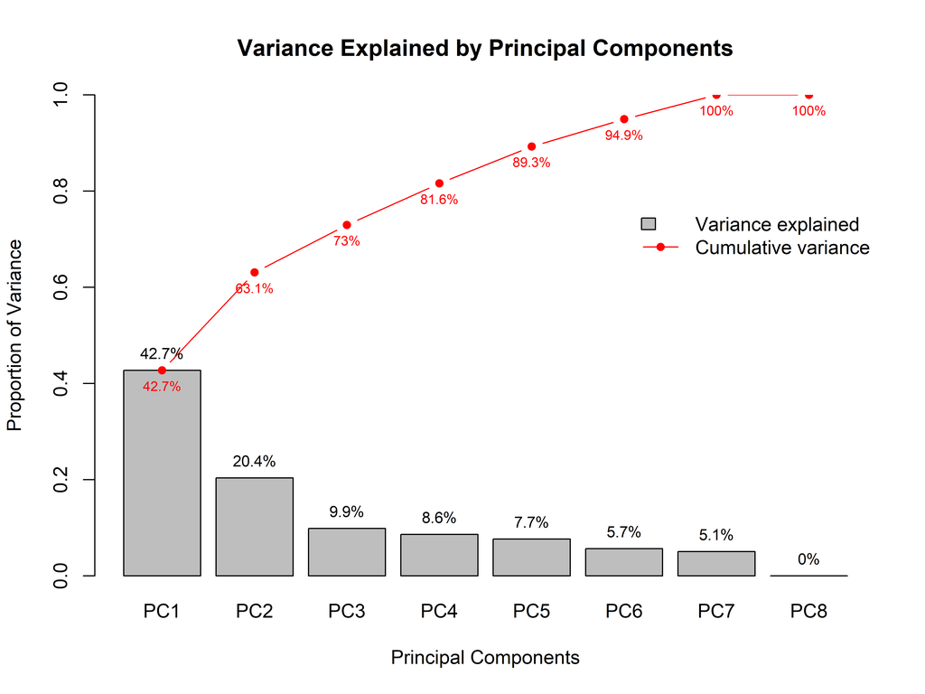

```r
bp <- barplot(
  pca_var_explained[1:8],
  names.arg = paste0("PC", 1:8),
  ylim = c(0, 1),
  main = "Variance Explained by Principal Components",
  xlab = "Principal Components",
  ylab = "Proportion of Variance"
)
text(
  bp,
  y = pca_var_explained[1:8],
  labels = paste0(round(pca_var_explained[1:8] * 100, 1), "%"),
  pos = 3,
  cex = 0.8
)

lines(
  x = bp,
  y = pca_var_cumulative[1:8],
  type = "b",
  pch = 16,
  col = "red"
)

text(
  bp,
  pca_var_cumulative[1:8],
  labels = paste0(round(pca_var_cumulative[1:8] * 100, 1), "%"),
  pos = 1,
  cex = 0.7,
  col = "red"
)

legend(
  x = bp[6],
  y = 0.78,
  legend = c("Variance explained", "Cumulative variance"),
  fill = c("grey", NA),
  border = c("black", NA),
  lty = c(NA, 1),
  pch = c(NA, 16),
  col = c("black", "red"),
  bty = "n"
)
```

**Interpretation:** PC1 explains 42.7% of the variance and PC2 explains 20.4%, so the first two principal components capture about 63.1% of the total variation in the normalized beta values. The cumulative variance line shows how much total variation is captured as additional principal components are included. This indicates that a small number of major sources explain much of the sample-to-sample variability. The PCA is therefore useful for checking whether this variation follows disease group, sex, or Sentrix_ID/batch patterns.

### 8.3 PCA Colored by Disease Group

Color the PCA by disease group to check whether CTRL and DIS samples separate globally.

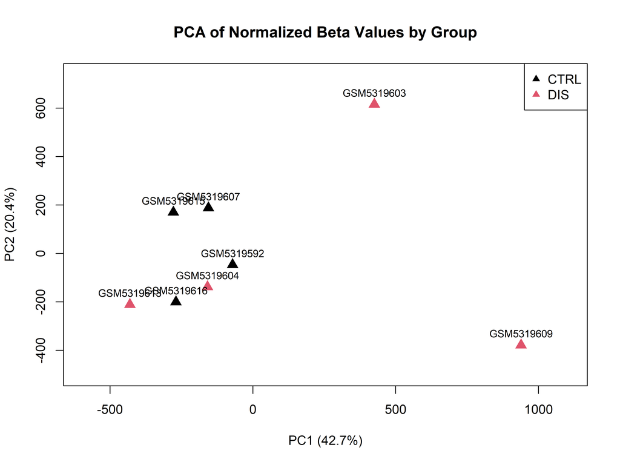

```r
plot(
  pca_results$x[, "PC1"],
  pca_results$x[, "PC2"],
  col = sample_info$Group,
  pch = 17,
  cex = 1.5,
  xlim = xlim_pca,
  ylim = ylim_pca,
  xlab = paste0(
    "PC1 (",
    round(pca_var_explained[1] * 100, 1),
    "%)"
  ),
  ylab = paste0(
    "PC2 (",
    round(pca_var_explained[2] * 100, 1),
    "%)"
  ),
  main = "PCA of Normalized Beta Values by Group"
)

text(
  pca_results$x[, "PC1"],
  pca_results$x[, "PC2"],
  labels = sample_info$SampleID,
  pos = 3,
  cex = 0.8
)

legend(
  "topright",
  legend = levels(sample_info$Group),
  col = seq_along(levels(sample_info$Group)),
  pch = 17
)
```

**Interpretation:** When the PCA is colored by disease group, CTRL and DIS samples do not form two clearly separated clusters. Samples from both groups appear across the main PCA space, and some samples are separated from the rest regardless of group label. This suggests that disease status is not the dominant source of global methylation variation in this dataset. Any disease-associated methylation differences are therefore likely to be CpG-specific or subtle rather than visible as a strong genome-wide shift in the first two principal components.

### 8.4 PCA Colored by Sex

Color the PCA by sex to check whether sex contributes to the major sample structure.

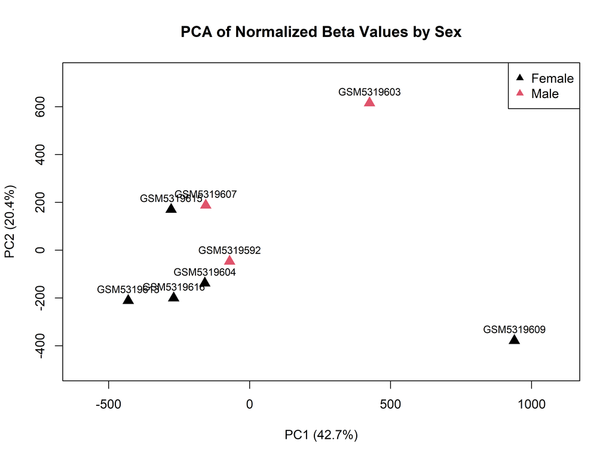

```r
plot(
  pca_results$x[, "PC1"],
  pca_results$x[, "PC2"],
  col = sample_info$Sex,
  pch = 17,
  cex = 1.5,
  xlim = xlim_pca,
  ylim = ylim_pca,
  xlab = paste0(
    "PC1 (",
    round(pca_var_explained[1] * 100, 1),
    "%)"
  ),
  ylab = paste0(
    "PC2 (",
    round(pca_var_explained[2] * 100, 1),
    "%)"
  ),
  main = "PCA of Normalized Beta Values by Sex"
)

text(
  pca_results$x[, "PC1"],
  pca_results$x[, "PC2"],
  labels = sample_info$SampleID,
  pos = 3,
  cex = 0.8
)

legend(
  "topright",
  legend = levels(sample_info$Sex),
  col = seq_along(levels(sample_info$Sex)),
  pch = 17
)
```

**Interpretation:** Coloring the PCA by sex shows that male and female samples contribute to the observed sample structure. The male samples tend to occupy distinct positions from several female samples, consistent with sex being an important biological source of methylation variation, partly because of sex-chromosome biology. However, the separation is not sufficient to explain all of the PCA structure by itself, so sex should be considered as a possible contributor rather than the only driver of variation.

### 8.5 PCA Colored by Batch (Slide)

Color the PCA by Sentrix_ID, stored in `pData(RGset)` as `Slide`, to check possible slide or batch structure.

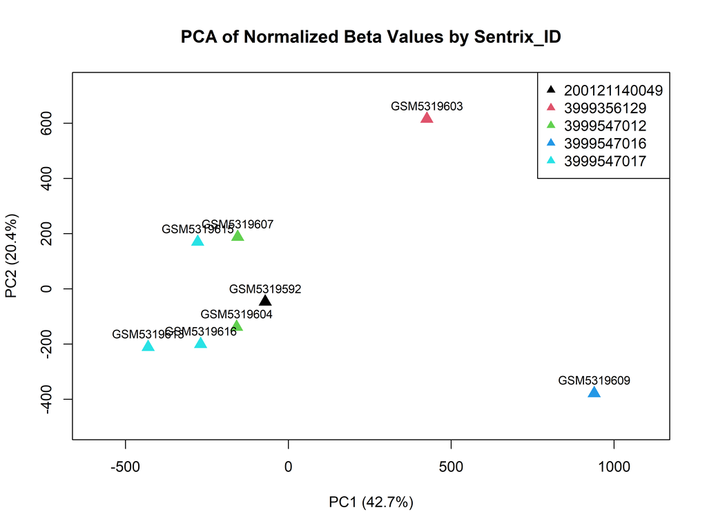

```r
plot(
  pca_results$x[, "PC1"],
  pca_results$x[, "PC2"],
  col = sample_info$Sentrix_ID,
  pch = 17,
  cex = 1.5,
  xlim = xlim_pca,
  ylim = ylim_pca,
  xlab = paste0(
    "PC1 (",
    round(pca_var_explained[1] * 100, 1),
    "%)"
  ),
  ylab = paste0(
    "PC2 (",
    round(pca_var_explained[2] * 100, 1),
    "%)"
  ),
  main = "PCA of Normalized Beta Values by Sentrix_ID"
)

text(
  pca_results$x[, "PC1"],
  pca_results$x[, "PC2"],
  labels = sample_info$SampleID,
  pos = 3,
  cex = 0.8
)

legend(
  "topright",
  legend = levels(sample_info$Sentrix_ID),
  col = seq_along(levels(sample_info$Sentrix_ID)),
  pch = 17
)
```

**Interpretation:** Coloring the PCA by Sentrix_ID shows that technical slide/batch information may contribute to the sample structure. Some samples sharing the same Sentrix_ID appear closer together, while other samples are separated more strongly along PC1 or PC2. This pattern suggests a possible batch effect, although it is not perfectly separated by slide for every sample. Since PC1 explains the largest fraction of variance, Sentrix_ID should be mentioned as a potential technical confounder. The downstream t-test results should therefore be interpreted cautiously, especially because the sample size is small and no additional batch-correction model was applied.

Because the PCA suggests that biological sex and Sentrix_ID/slide may contribute to the observed sample structure, the simple probe-wise t-test comparing only CTRL and DIS should be interpreted cautiously. These variables may act as potential confounders, especially in a small dataset where each sample has a strong influence on the analysis.

In a future, more robust analysis, rather than relying only on a simple t-test, it would be recommended to use a linear modeling approach, such as `limma`, to adjust for relevant covariates. This would help separate disease-associated methylation differences from variation related to sex or technical slide/batch effects.

## Step 09. Differential Methylation Analysis with t-test

Differential methylation analysis identifies CpG-specific changes associated with disease status. Here, probe-wise t-tests compare normalized beta values between CTRL and DIS samples.

Use the normalized beta values from Step 07 and the sample information prepared in Step 08.

```r
beta_matrix <- beta_preprocessNoob
sample_data <- sample_info
```

Identify CTRL and DIS samples for the t-test comparison.

```r
control_samples <- sample_data$Group == "CTRL"
disease_samples <- sample_data$Group == "DIS"
```

Calculate the mean beta value for each CpG probe in each group and compute the methylation difference.

```r
mean_ctrl <- rowMeans(
  beta_matrix[, control_samples],
  na.rm = TRUE
)

mean_dis <- rowMeans(
  beta_matrix[, disease_samples],
  na.rm = TRUE
)

delta_beta <- mean_dis - mean_ctrl
```

Define a t-test function for one CpG probe and apply it to every row of the beta matrix.

```r
My_ttest_function <- function(probe_values) {
  t_test <- t.test(
    probe_values[control_samples],
    probe_values[disease_samples]
  )
  return(t_test$p.value)
}

p_values <- apply(
  beta_matrix,
  1,
  My_ttest_function
)
```

Combine group means, delta beta values, and nominal p-values into one results table.

```r
t_test_results <- data.frame(
  ProbeID = rownames(beta_matrix),
  Mean_CTRL = mean_ctrl,
  Mean_DIS = mean_dis,
  Delta_Beta = delta_beta,
  P_Value = p_values
)

Nominal_Significant_Probes <- sum(t_test_results$P_Value <= 0.05, na.rm = TRUE)

head(t_test_results)
```

|  | ProbeID | Mean_CTRL | Mean_DIS | Delta_Beta | P_Value |
| --- | --- | --- | --- | --- | --- |
| cg00050873 | cg00050873 | 0.7725437 | 0.6650294 | -0.10751427 | 0.4915801 |
| cg00212031 | cg00212031 | 0.2674977 | 0.3594515 | 0.09195380 | 0.5667777 |
| cg00213748 | cg00213748 | 0.6393461 | 0.5544797 | -0.08486642 | 0.4329115 |
| cg00214611 | cg00214611 | 0.2857371 | 0.3975290 | 0.11179193 | 0.5359672 |
| cg00455876 | cg00455876 | 0.5932794 | 0.3887466 | -0.20453279 | 0.2706024 |
| cg01707559 | cg01707559 | 0.1918039 | 0.2168073 | 0.02500346 | 0.8228851 |

```r
Nominal_Significant_Probes
```

```
## [1] 11928
```

**Interpretation:** The probe-wise t-test produced results for 485512 CpG probes. At the nominal threshold of `P_Value <= 0.05`, 11928 probes are significant before correction. These nominal results suggest candidate CpGs that may differ between CTRL and DIS samples, but they cannot be treated as final significant findings because hundreds of thousands of tests were performed. Multiple testing correction is therefore required in Step 10.

In Step 9, the script runs the t-test on the normalized beta matrix. Beta values are highly intuitive because they range from 0 to 1 and allow direct interpretation of methylation differences, including `Delta_Beta`. However, beta values can be affected by heteroscedasticity near the extreme ends of the scale, close to 0 and 1.

This dataset is small, with 8 samples in total and 4 samples per group. M-values are generally considered more suitable for statistical testing because they are often more homoscedastic than beta values. Therefore, while we performed the differential analysis using normalized beta values to keep the biological effect size easy to interpret, M-value-based testing could be considered in a future analysis and might yield slightly different statistical sensitivity.

## Step 10. Multiple Testing Correction

Multiple testing correction is applied to the t-test p-values because the analysis tests hundreds of thousands of CpG probes. We compare the nominal p-values with Bonferroni and Benjamini-Hochberg adjusted p-values using the Team 1 threshold of 0.05.

Define the significance threshold assigned to Team 1.

```r
alpha <- 0.05
alpha
```

```
## [1] 0.05
```

Apply Bonferroni and Benjamini-Hochberg corrections to the t-test p-values.

```r
t_test_results$P_Bonferroni <- p.adjust(t_test_results$P_Value, method = "bonferroni")
t_test_results$P_BH <- p.adjust(t_test_results$P_Value, method = "BH")

head(t_test_results[, c("ProbeID", "P_Value", "P_Bonferroni", "P_BH")])
```

|  | ProbeID | P_Value | P_Bonferroni | P_BH |
| --- | --- | --- | --- | --- |
| cg00050873 | cg00050873 | 0.4915801 | 1 | 0.8255669 |
| cg00212031 | cg00212031 | 0.5667777 | 1 | 0.8422310 |
| cg00213748 | cg00213748 | 0.4329115 | 1 | 0.8242394 |
| cg00214611 | cg00214611 | 0.5359672 | 1 | 0.8334069 |
| cg00455876 | cg00455876 | 0.2706024 | 1 | 0.8242394 |
| cg01707559 | cg01707559 | 0.8228851 | 1 | 0.9385672 |

Visualize the distribution of nominal and corrected p-values.

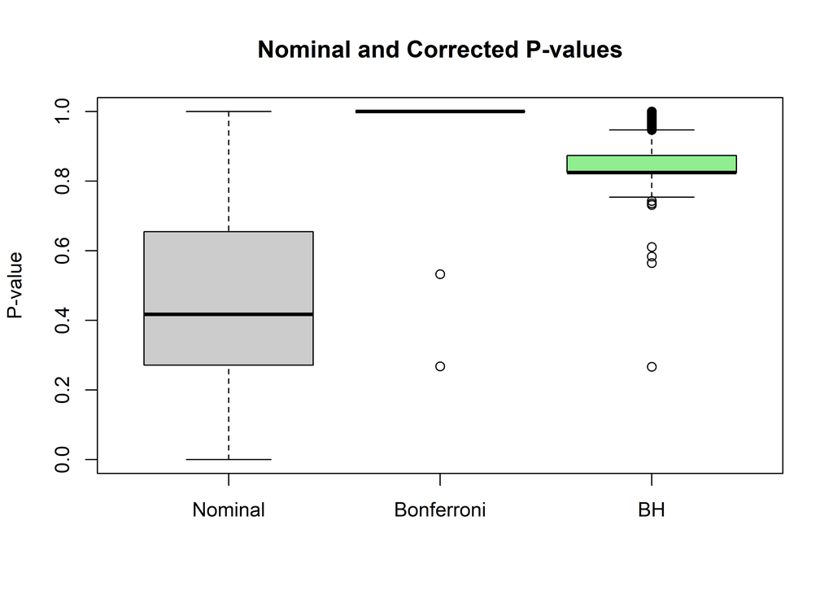

```r
boxplot(
  t_test_results[, c("P_Value", "P_Bonferroni", "P_BH")],
  names = c("Nominal", "Bonferroni", "BH"),
  col = c("grey80", "lightblue", "lightgreen"),
  ylab = "P-value",
  main = "Nominal and Corrected P-values"
)
```

Count how many probes are significant before and after multiple testing correction.

```r
sig_nominal <- sum(t_test_results$P_Value <= alpha, na.rm = TRUE)
sig_bonferroni <- sum(t_test_results$P_Bonferroni <= alpha, na.rm = TRUE)
sig_bh <- sum(t_test_results$P_BH <= alpha, na.rm = TRUE)

correction_summary <- data.frame(
  Method = c("Nominal p-value", "Bonferroni", "Benjamini-Hochberg"),
  Threshold = alpha,
  Significant_Probes = c(sig_nominal, sig_bonferroni, sig_bh)
)

correction_summary
```

| Method | Threshold | Significant_Probes |
| --- | --- | --- |
| Nominal p-value | 0.05 | 11928 |
| Bonferroni | 0.05 | 0 |
| Benjamini-Hochberg | 0.05 | 0 |

**Interpretation:** The t-test identified 11928 probes with nominal `P_Value <= 0.05`. However, after correcting for the 485512 simultaneous CpG-level tests, 0 probes remained significant using Bonferroni correction and 0 probes remained significant using Benjamini-Hochberg correction at the 0.05 threshold.

This result shows why multiple testing correction is essential in methylation-array analysis. With hundreds of thousands of CpGs tested, some small p-values can occur by chance. Bonferroni is very strict because it controls the family-wise error rate, while Benjamini-Hochberg controls the false discovery rate and is usually less conservative. In this dataset, neither correction retained significant probes, suggesting that the disease-associated signal is weak relative to the small sample size, variability, and possible technical structure. Therefore, the nominally significant probes should be treated as exploratory candidates only, not as genome-wide significant differentially methylated probes.

## Step 11. Volcano and Manhattan Plots

Volcano and Manhattan plots are used to visualize the differential methylation results from the t-test. Since no probes remained significant after multiple testing correction, these plots are interpreted using nominal p-values only as exploratory evidence.

### 11.1 Volcano Plot

The volcano plot compares the methylation effect size (`Delta_Beta`, DIS - CTRL) with the nominal statistical evidence (`-log10(P_Value)`). We highlight exploratory candidate probes using nominal `P_Value <= 0.05` and `|Delta_Beta| > 0.1`.

Prepare the exploratory candidates and produce the volcano plot.

```r
delta_beta_threshold <- 0.1

hyper <- which(
  t_test_results$Delta_Beta > delta_beta_threshold &
    t_test_results$P_Value <= alpha
)

hypo <- which(
  t_test_results$Delta_Beta < -delta_beta_threshold &
    t_test_results$P_Value <= alpha
)

volcano_summary <- data.frame(
  Category = c("Hypermethylated in DIS", "Hypomethylated in DIS"),
  Delta_Beta_Threshold = c(delta_beta_threshold, -delta_beta_threshold),
  P_Value_Threshold = alpha,
  Candidate_Probes = c(length(hyper), length(hypo))
)

volcano_summary
```

| Category | Delta_Beta_Threshold | P_Value_Threshold | Candidate_Probes |
| --- | --- | --- | --- |
| Hypermethylated in DIS | 0.1 | 0.05 | 2777 |
| Hypomethylated in DIS | -0.1 | 0.05 | 1800 |

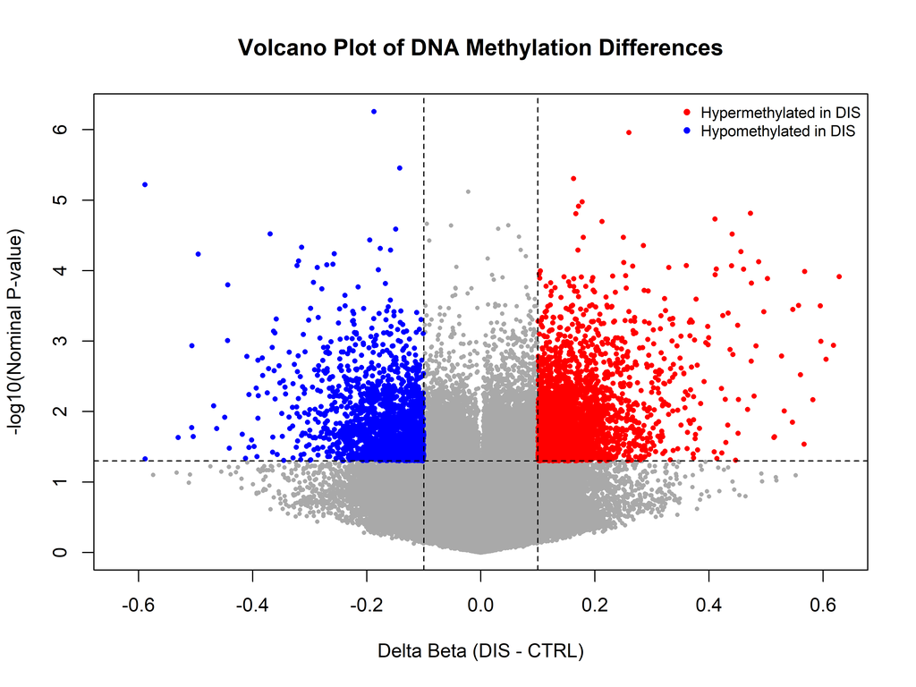

```r
plot(
  x = t_test_results$Delta_Beta,
  y = -log10(t_test_results$P_Value),
  pch = 16,
  cex = 0.5,
  col = "darkgray",
  xlab = "Delta Beta (DIS - CTRL)",
  ylab = "-log10(Nominal P-value)",
  main = "Volcano Plot of DNA Methylation Differences",
  xlim = c(
    -max(abs(t_test_results$Delta_Beta), na.rm = TRUE),
    max(abs(t_test_results$Delta_Beta), na.rm = TRUE)
  )
)

points(
  t_test_results$Delta_Beta[hyper],
  -log10(t_test_results$P_Value)[hyper],
  col = "red",
  pch = 16,
  cex = 0.6
)

points(
  t_test_results$Delta_Beta[hypo],
  -log10(t_test_results$P_Value)[hypo],
  col = "blue",
  pch = 16,
  cex = 0.6
)

abline(h = -log10(alpha), col = "black", lty = 2)
abline(v = c(-delta_beta_threshold, delta_beta_threshold), col = "black", lty = 2)

legend(
  "topright",
  legend = c("Hypermethylated in DIS", "Hypomethylated in DIS"),
  col = c("red", "blue"),
  pch = 16,
  cex = 0.8,
  bty = "n"
)
```

**Interpretation:** The volcano plot shows probes with both nominal statistical evidence and larger methylation differences between DIS and CTRL samples. Red points represent probes with higher methylation in DIS samples, while blue points represent probes with lower methylation in DIS samples. Using the exploratory thresholds, there are 2777 hypermethylated and 1800 hypomethylated candidate probes. These loci may be useful for follow-up or visualization, but they should not be reported as genome-wide significant because none remained significant after Bonferroni or Benjamini-Hochberg correction.

### 11.2 Manhattan Plot

The Manhattan plot displays the nominal t-test p-values across genomic coordinates. To build the plot, genomic annotation is merged with the t-test results using the CpG probe ID.

Add chromosome and position information to the t-test results and produce the Manhattan plot.

```r
ann <- getAnnotation(preprocessNoob_results)

locations <- data.frame(
  ProbeID = rownames(ann),
  CHR = ann$chr,
  MAPINFO = ann$pos
)

manhattan_data <- merge(t_test_results, locations, by = "ProbeID")

order_chr <- c(as.character(1:22), "X", "Y")
manhattan_data$CHR <- gsub("chr", "", manhattan_data$CHR)
manhattan_data$CHR <- factor(manhattan_data$CHR, levels = order_chr)
manhattan_data$CHR <- as.numeric(manhattan_data$CHR)

manhattan_data <- manhattan_data[
  !is.na(manhattan_data$CHR) &
    !is.na(manhattan_data$MAPINFO) &
    !is.na(manhattan_data$P_Value),
]

head(manhattan_data[, c("ProbeID", "CHR", "MAPINFO", "P_Value")])
```

|  | ProbeID | CHR | MAPINFO | P_Value |
| --- | --- | --- | --- | --- |
| 1 | cg00000029 | 16 | 53468112 | 0.7953471 |
| 2 | cg00000108 | 3 | 37459206 | 0.3289001 |
| 3 | cg00000109 | 3 | 171916037 | 0.4272806 |
| 4 | cg00000165 | 1 | 91194674 | 0.4744624 |
| 5 | cg00000236 | 8 | 42263294 | 0.1673485 |
| 6 | cg00000289 | 14 | 69341139 | 0.5163404 |

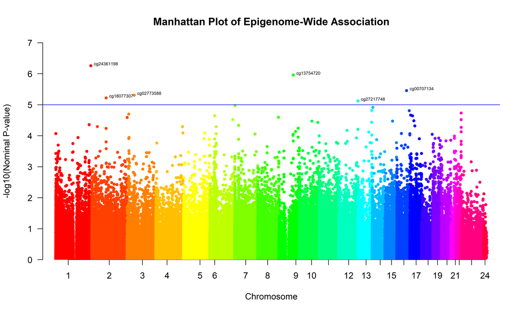

```r
manhattan(
  manhattan_data,
  chr = "CHR",
  bp = "MAPINFO",
  snp = "ProbeID",
  p = "P_Value",
  col = rainbow(length(order_chr)),
  suggestiveline = -log10(0.00001),
  genomewideline = FALSE,
  annotatePval = 0.00001,
  main = "Manhattan Plot of Epigenome-Wide Association",
  ylab = "-log10(Nominal P-value)"
)
```

**Interpretation:** The Manhattan plot displays the nominal t-test p-values across genomic coordinates. The points are broadly distributed across chromosomes, with several local peaks reaching low nominal p-values. However, because no genome-wide or FDR-significant probes were identified after correction, these peaks should be interpreted as suggestive rather than definitive disease-associated regions. The plot is useful for visualizing where the strongest nominal signals occur, but it does not provide corrected-significant genomic loci in this dataset.

## Step 12. Heatmap of the Top 100 CpGs

To visualize the strongest candidate methylation patterns, we select the top 100 CpG probes ranked by nominal t-test p-value. These probes are used for hierarchical clustering of both probes and samples.

Select the top 100 CpG probes ranked by nominal p-value.

```r
nominal_t_test_results <- t_test_results[t_test_results$P_Value <= alpha, ]
top_100_results <- nominal_t_test_results[order(nominal_t_test_results$P_Value), ][1:100, ]
top_100_probes <- top_100_results$ProbeID

head(top_100_results)
```

|  | ProbeID | Mean_CTRL | Mean_DIS | Delta_Beta | P_Value | P_Bonferroni | P_BH |
| --- | --- | --- | --- | --- | --- | --- | --- |
| cg24361198 | cg24361198 | 0.93352103 | 0.74599637 | -0.18752465 | 5.519819e-07 | 0.2679938 | 0.2664912 |
| cg13754720 | cg13754720 | 0.65699851 | 0.91634025 | 0.25934175 | 1.097774e-06 | 0.5329824 | 0.2664912 |
| cg00707134 | cg00707134 | 0.45995834 | 0.31759012 | -0.14236822 | 3.487582e-06 | 1.0000000 | 0.5644210 |
| cg02773588 | cg02773588 | 0.80730329 | 0.96974249 | 0.16243920 | 4.918031e-06 | 1.0000000 | 0.5834406 |
| cg18077307 | cg18077307 | 0.77509956 | 0.18632581 | -0.58877376 | 6.008509e-06 | 1.0000000 | 0.5834406 |
| cg27217748 | cg27217748 | 0.05578254 | 0.03341282 | -0.02236973 | 7.551578e-06 | 1.0000000 | 0.6110637 |

Extract the normalized beta values for these probes and prepare the group color annotation.

```r
beta_top100 <- beta_preprocessNoob[top_100_probes, ]
input_heatmap <- as.matrix(beta_top100)

heatmap_group_colors <- c(CTRL = "royalblue", DIS = "orange")
colorbar <- heatmap_group_colors[as.character(sample_info$Group)]
heatmap_palette <- colorRampPalette(c("green", "black", "red"))(100)

dim(input_heatmap)
```

```
## [1] 100   8
```

### 12.1 Complete Linkage Heatmap

Produce the heatmap using complete linkage clustering.

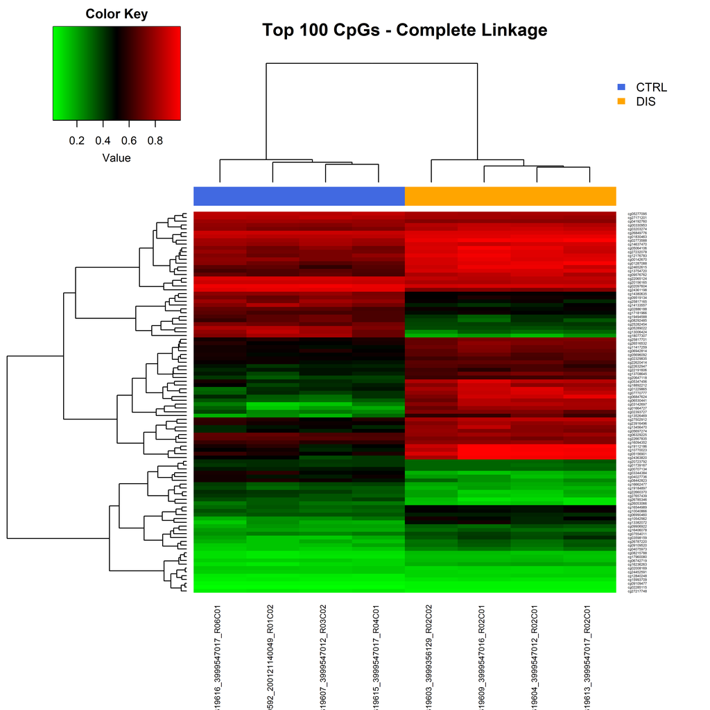

```r
heatmap.2(
  input_heatmap,
  col = heatmap_palette,
  Rowv = TRUE,
  Colv = TRUE,
  dendrogram = "both",
  key = TRUE,
  ColSideColors = colorbar,
  density.info = "none",
  trace = "none",
  scale = "none",
  symm = FALSE,
  margins = c(10, 8),
  cexCol = 0.8,
  cexRow = 0.35,
  labRow = rownames(input_heatmap),
  main = "Top 100 CpGs - Complete Linkage"
)

legend(
  "topright",
  legend = names(heatmap_group_colors),
  fill = heatmap_group_colors,
  border = FALSE,
  bty = "n",
  cex = 0.8
)
```

### 12.2 Single Linkage Heatmap

Produce the heatmap using single linkage clustering.

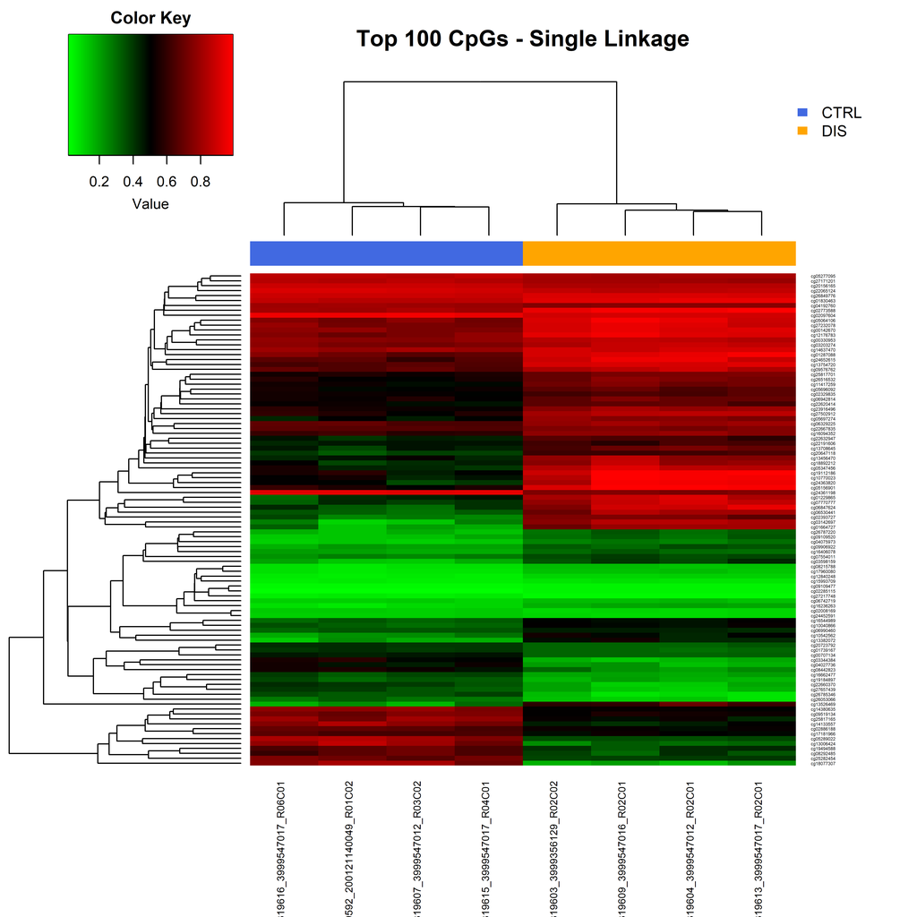

```r
heatmap.2(
  input_heatmap,
  col = heatmap_palette,
  Rowv = TRUE,
  Colv = TRUE,
  hclustfun = function(x) hclust(x, method = "single"),
  dendrogram = "both",
  key = TRUE,
  ColSideColors = colorbar,
  density.info = "none",
  trace = "none",
  scale = "none",
  symm = FALSE,
  margins = c(10, 8),
  cexCol = 0.8,
  cexRow = 0.35,
  labRow = rownames(input_heatmap),
  main = "Top 100 CpGs - Single Linkage"
)

legend(
  "topright",
  legend = names(heatmap_group_colors),
  fill = heatmap_group_colors,
  border = FALSE,
  bty = "n",
  cex = 0.8
)
```

### 12.3 Average Linkage Heatmap

Produce the heatmap using average linkage clustering.

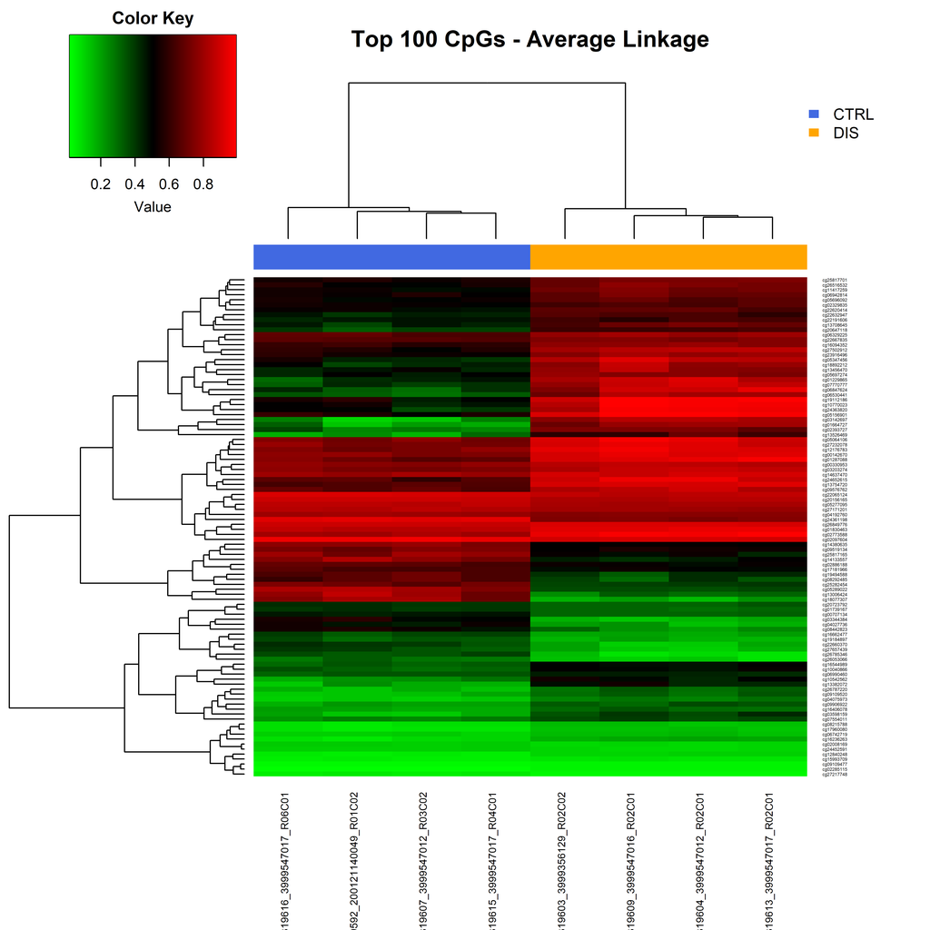

```r
heatmap.2(
  input_heatmap,
  col = heatmap_palette,
  Rowv = TRUE,
  Colv = TRUE,
  hclustfun = function(x) hclust(x, method = "average"),
  dendrogram = "both",
  key = TRUE,
  ColSideColors = colorbar,
  density.info = "none",
  trace = "none",
  scale = "none",
  symm = FALSE,
  margins = c(10, 8),
  cexCol = 0.8,
  cexRow = 0.35,
  labRow = rownames(input_heatmap),
  main = "Top 100 CpGs - Average Linkage"
)

legend(
  "topright",
  legend = names(heatmap_group_colors),
  fill = heatmap_group_colors,
  border = FALSE,
  bty = "n",
  cex = 0.8
)
```

**Interpretation:** We generated heatmaps comparing three different agglomerative hierarchical clustering methods: Complete, Average, and Single-linkage, to visually assess the robustness of our top 100 nominally significant probes.

As seen in the dendrograms for both the Complete and Average linkage heatmaps, the samples split into two distinct branches: one containing CTRL samples (blue) and the other containing DIS samples (orange). This is an important exploratory finding because, while the earlier PCA showed that global methylation variance may also be influenced by sex and Sentrix_ID/slide effects, these heatmaps suggest that isolating the top 100 nominally significant probes captures a coordinated group-associated methylation pattern.

The Single-linkage heatmap also shows separation between CTRL and DIS samples, but it displays a more chaining-like structure, where samples or clusters are sequentially joined based on the closest individual points. As discussed in the course, Single-linkage can be more susceptible to noise and outliers because it joins clusters using the minimum distance between them. Therefore, Complete and Average linkage provide more compact and visually interpretable clustering patterns for this high-dimensional methylation dataset.

However, these heatmaps remain exploratory because the probes were selected using nominal p-values, and Step 10 showed that no CpG remained significant after Bonferroni or Benjamini-Hochberg correction. Therefore, the heatmaps support a candidate group-associated methylation structure, but they do not override the multiple-testing result.

# Conclusion

This report completed the required Team 1 workflow for the Illumina 450K methylation array dataset. The raw Red and Green fluorescence values were inspected for the assigned address, raw methylated and unmethylated signals were converted into `MSet.raw`, and quality control was performed using median signal intensities, negative controls, and detection p-values. The detection p-value results indicated a low fraction of failed probe-sample tests, supporting retention of the samples for downstream analysis.

Normalization was performed with the assigned `preprocessNoob` method. The raw and normalized beta-value comparisons showed expected methylation distributions and no obvious normalization-induced separation between CTRL and DIS samples. PCA suggested that disease group was not the dominant source of global methylation variation, while sex and Sentrix_ID/slide information may contribute to the observed sample structure.

Probe-wise t-tests identified nominally significant CpG candidates between CTRL and DIS samples, but no probes remained significant after Bonferroni or Benjamini-Hochberg correction at the 0.05 threshold. Therefore, the volcano plot, Manhattan plot, and heatmaps should be interpreted as exploratory visualizations of candidate methylation patterns rather than evidence of genome-wide significant differentially methylated probes. Overall, the analysis fulfills the assigned pipeline and provides a reproducible exploratory summary of the dataset, while indicating that a larger study or a model including relevant covariates would be needed to confirm any candidate disease-associated methylation signals.

# Code and Data Availability

The source code, tracked input files, intermediate R objects, tables, figures, and rendered report for this project are available in the Team 1 GitHub repository:

Bayat, F., Eter, T., Golshani, S. P., Heidari, A., Ibrahim, M. A. M. M., Parga Najera, H. E., Rahmani, B., & Zanjaniha, S. (2026). *Team 1 final project: DNA methylation analysis of CTRL and DIS samples using Illumina HumanMethylation450K arrays*. DNA & RNA Dynamics course, Alma Mater Studiorum - Universita di Bologna. GitHub repository: Parganini/DRD-Final-Project-Team1.